# Árboles de regresión

29 octubre 2019

# 1 Estimación de los árboles de regresión

## 1.1 La función rpart

```r
library(rpart)
d = read.table('datos/coches.txt', header = T)
d = na.omit(d)
d$origen = factor(d$origen, labels = c("USA","Europa","Japon"))
```

```r
# method = "anova" para modelos de regresion
t1 = rpart(consumo ~ ., data = d, method = "anova")
```

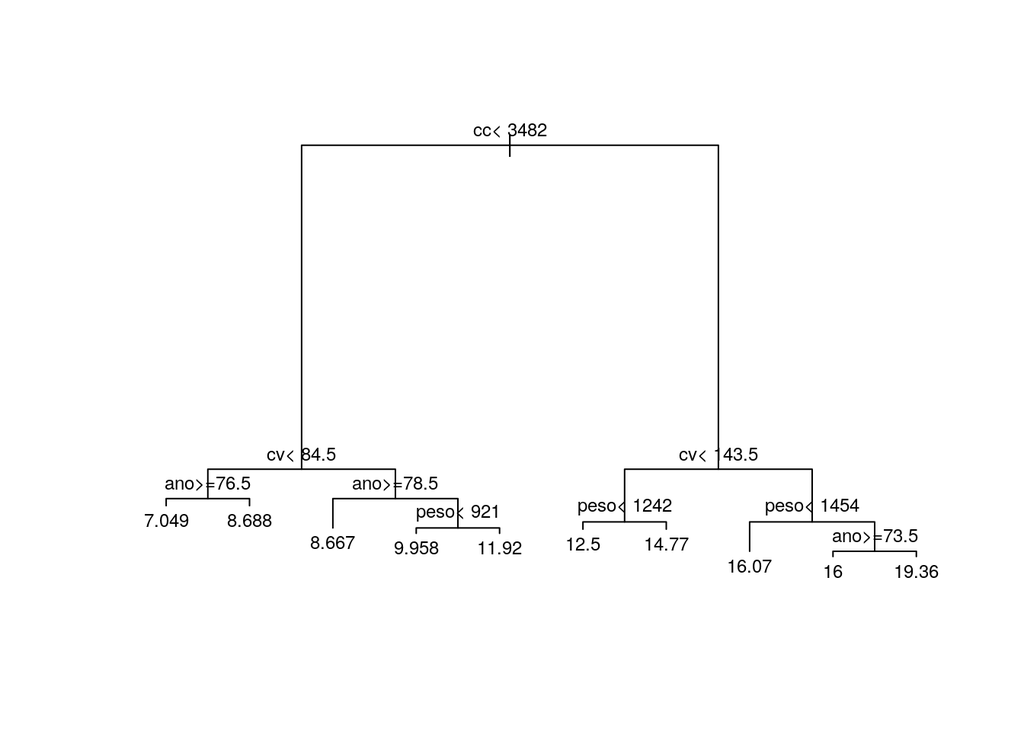

```r
plot(t1, margin = 0.02)
text(t1, cex = 0.75)
```

- Los regresores que son influyentes en el consumo son los que se han empleado en las particiones.

```r
print(t1)
```

```
## n= 391
##
## node), split, n, deviance, yval
##       * denotes terminal node
##
##  1) root 391 5910.74200 11.227620
##    2) cc< 3482 234  856.23930  8.709402
##      4) cv< 84.5 129  216.99220  7.658915
##        8) ano>=76.5 81   81.80247  7.049383 *
##        9) ano< 76.5 48   54.31250  8.687500 *
##      5) cv>=84.5 105  322.00000 10.000000
##       10) ano>=78.5 33   67.33333  8.666667 *
##       11) ano< 78.5 72  169.11110 10.611110
##         22) peso< 921 48   69.91667  9.958333 *
##         23) peso>=921 24   37.83333 11.916670 *
##    3) cc>=3482 157 1358.94300 14.980890
##      6) cv< 143.5 82  358.01220 13.109760
##       12) peso< 1242 60  185.00000 12.500000 *
##       13) peso>=1242 22   89.86364 14.772730 *
##      7) cv>=143.5 75  399.94670 17.026670
##       14) peso< 1453.5 46  132.80430 16.065220 *
##       15) peso>=1453.5 29  157.17240 18.551720
##         30) ano>=73.5 7   12.00000 16.000000 *
##         31) ano< 73.5 22   85.09091 19.363640 *
```

Lo que devuelve la tabla es:

- Numero del nodo
- split: criterio para hacer la partición del nodo
- n: numero de datos que componen el nodo.
- deviance: = RSS = $\sum(y_i - \hat{y}_i)^2$.

```r
n = nrow(d)
( deviance_root = sum( (d$consumo - mean(d$consumo))^2 ) )
```

```
## [1] 5910.742
```

- yval: predicción del nodo = $\bar{y}$

```r
mean(d$consumo)
```

```
## [1] 11.22762
```

- un asterisco * para indicar un nodo terminal u hoja.

## 1.2 Parámetros del árbol

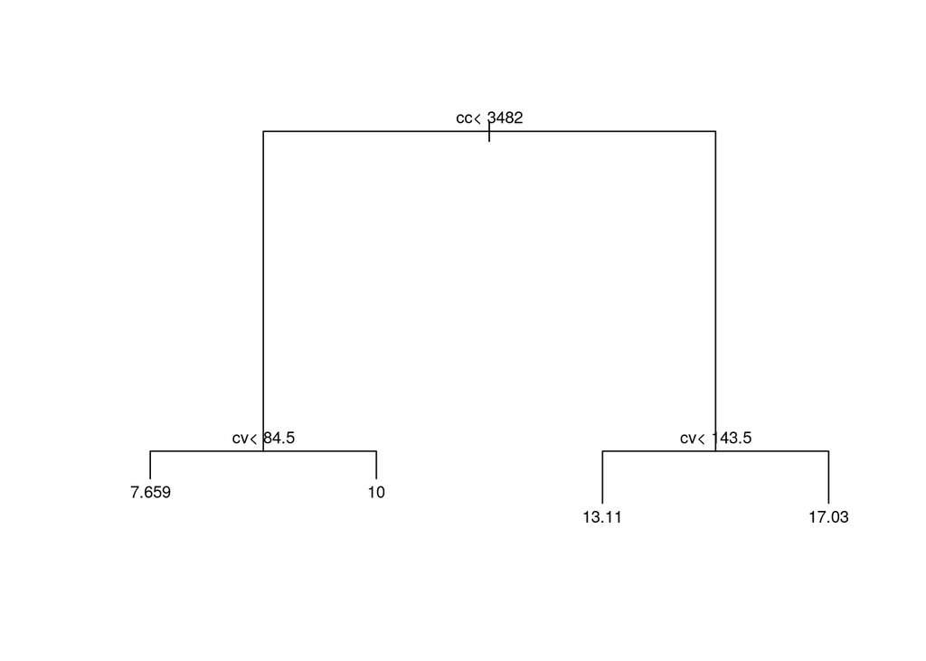

```r
t2 = rpart(consumo ~ ., data = d, method = "anova",
    control = rpart.control(minsplit = 10, minbucket = 5, cp = 0.05))
plot(t2, margin = 0.02)
text(t2, cex=.75)
```

control:

- minsplit: número mínimo de observaciones del nodo para que se divida en dos (por defecto, minsplit = 20).
- minbucket: número mínimo de observaciones en un nodo terminal u hoja (por defecto, minbucket = minsplit/3).
- maxdev: se fija el nivel máximo de cualquier nodo del árbol, siendo 0 el nivel del nodo raiz.
- cp: complexity parameter. En árboles de regresión, para que un nodo se divida, el R2 tiene que incrementarse en más de cp (por defecto, cp = 0.01). En este caso: [RSS(padre) - RSS(hijo1) - RSS(hijo2)]/RSS(raiz) > cp
- xval: número de validaciones cruzadas. Se utiliza para el podado.

```r
print(t2)
```

```
## n= 391
##
## node), split, n, deviance, yval
##       * denotes terminal node
##
## 1) root 391 5910.7420 11.227620
##   2) cc< 3482 234  856.2393  8.709402
##     4) cv< 84.5 129  216.9922  7.658915 *
##     5) cv>=84.5 105  322.0000 10.000000 *
##   3) cc>=3482 157 1358.9430 14.980890
##     6) cv< 143.5 82  358.0122 13.109760 *
##     7) cv>=143.5 75  399.9467 17.026670 *
```

- Como vemos, en este caso el criterio que detiene el crecimiento del árbol es cp. Por ejemplo, el nodo 3 se ha dividido ya que

```r
(1358.94 - 358.01 - 399.94)/5910.74
```

```
## [1] 0.1016776
```

- que es mayor que el límite cp = 0.05.
- Podemos construir un arbol más *profundo*:

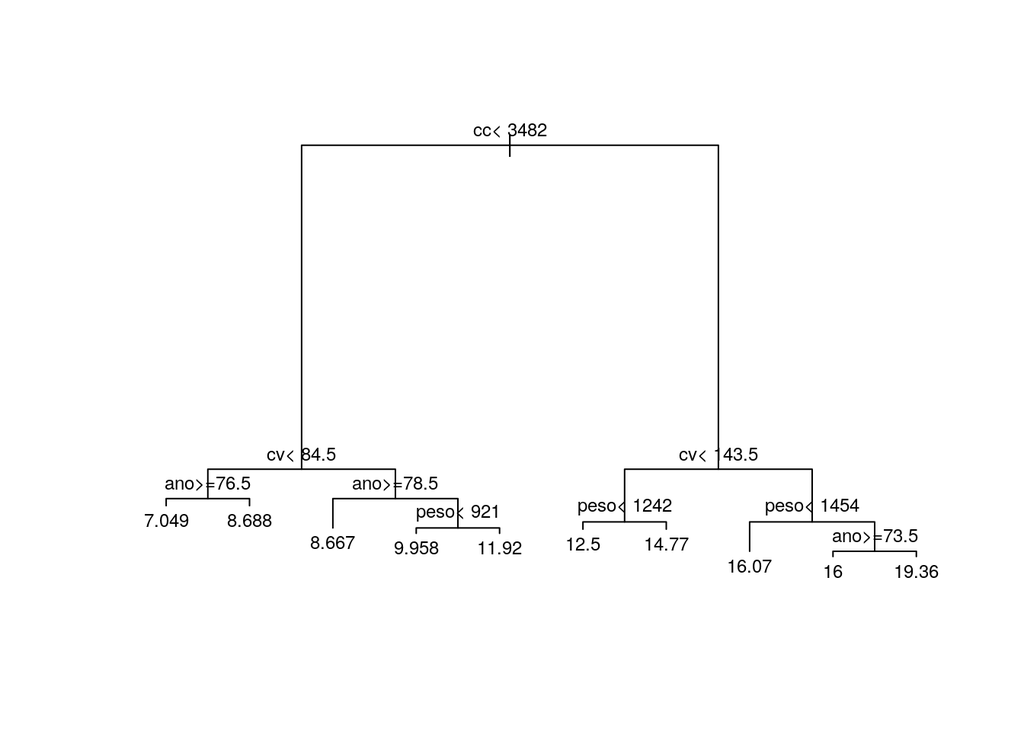

```r
t3 = rpart(consumo ~ ., data = d, method = "anova",
    control = rpart.control(minsplit = 10, minbucket = 5, cp = 0.01))
plot(t3, margin = 0.02)
text(t3, cex=.75)
```

```r
print(t3)
```

```
## n= 391
##
## node), split, n, deviance, yval
##       * denotes terminal node
##
##  1) root 391 5910.74200 11.227620
##    2) cc< 3482 234  856.23930  8.709402
##      4) cv< 84.5 129  216.99220  7.658915
##        8) ano>=76.5 81   81.80247  7.049383 *
##        9) ano< 76.5 48   54.31250  8.687500 *
##      5) cv>=84.5 105  322.00000 10.000000
##       10) ano>=78.5 33   67.33333  8.666667 *
##       11) ano< 78.5 72  169.11110 10.611110
##         22) peso< 921 48   69.91667  9.958333 *
##         23) peso>=921 24   37.83333 11.916670 *
##    3) cc>=3482 157 1358.94300 14.980890
##      6) cv< 143.5 82  358.01220 13.109760
##       12) peso< 1242 60  185.00000 12.500000 *
##       13) peso>=1242 22   89.86364 14.772730 *
##      7) cv>=143.5 75  399.94670 17.026670
##       14) peso< 1453.5 46  132.80430 16.065220 *
##       15) peso>=1453.5 29  157.17240 18.551720
##         30) ano>=73.5 7   12.00000 16.000000 *
##         31) ano< 73.5 22   85.09091 19.363640 *
```

- vemos que el nodo 7 en t2 no se dividía pero en t3 si se divide ya que:

```r
(399.94 - 132.80 - 157.17)/5910.74
```

```
## [1] 0.01860512
```

- De nuevo cp es el parámetro más restrictivo.

## 1.3 Residuos

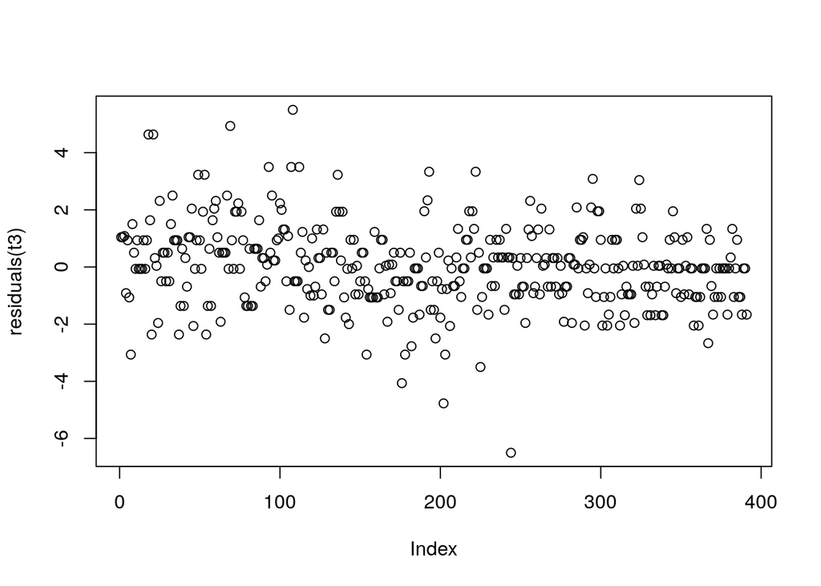

```r
plot(residuals(t3))
```

- El R2 se define a manera análoga a regresión

$$R^2 = 1 - \frac{RSS}{TSS}$$

- donde hay que recordar de RSS = deviance(nodo) y TSS = deviance(root)
- Se denomina error relativo al cociente RSS/TSS. Y la X indica que se ha calculado mediante validación cruzada.

```r
par(mfrow = c(1,2))
rsq.rpart(t3)
```

```
##
## Regression tree:
## rpart(formula = consumo ~ ., data = d, method = "anova", control = rpart.control(minsplit = 10,
##     minbucket = 5, cp = 0.01))
##
## Variables actually used in tree construction:
## [1] ano  cc   cv   peso
##
## Root node error: 5910.7/391 = 15.117
##
## n= 391
##
##          CP nsplit rel error  xerror     xstd
## 1  0.625228      0   1.00000 1.00607 0.067288
## 2  0.101677      1   0.37477 0.39733 0.032330
## 3  0.053673      2   0.27310 0.31494 0.025133
## 4  0.018605      3   0.21942 0.25252 0.022073
## 5  0.014475      4   0.20082 0.24345 0.021894
## 6  0.014067      5   0.18634 0.24080 0.021982
## 7  0.013683      6   0.17228 0.23260 0.021767
## 8  0.010381      7   0.15859 0.21896 0.021282
## 9  0.010165      8   0.14821 0.21511 0.021024
## 10 0.010000      9   0.13805 0.21590 0.021003
```

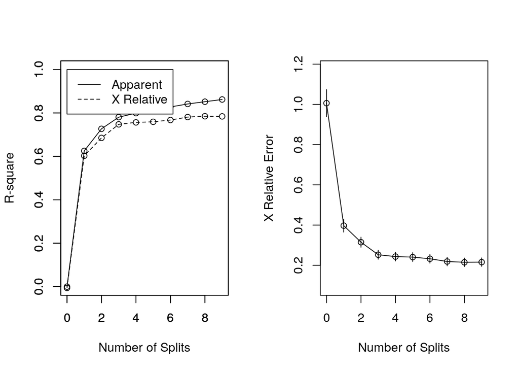

- Appatent: R2 calculado con la formula (1 - RSS/TSS)
- X Relative: R2 calculado con validación cruzada (como vemos, el R2 cuadrado con validación cruzada es menor que el apparent ya que uno esta calculado en los datos train y otro en los datos test).
- X relative error: 1 - X Relative, es decir, RSS/TSS. Está calculado con validación cruzada. Se dibuja el intervalo +/- SE calculado con validación cruzada.

# 2 Podado

- Los árboles que hemos visto se construyen de arriba hacia abajo, desde el nodo raiz hasta las hojas. Otra estrategia es construir un arbol muy profundo y luego podarlo. Construiriamos el arbol, por tanto, de abajo hacia arriba.
- Primero construimos un arbol profundo:

```r
t4 = rpart(consumo ~ ., data = d, method = "anova",
    control = rpart.control(minsplit = 2, cp = 0.001))
```

- Utilizando validación cruzada (el numero de validaciones viene dado por el parámetro xval), se determina el arbol con un determinado numero de hojas que tenga el mayor R2, o de manera equivalente, el menor error relativo.

```r
t4_printcp = printcp(t4) # lo guardamos en una variable para utilizarlo despues
```

```
##
## Regression tree:
## rpart(formula = consumo ~ ., data = d, method = "anova", control = rpart.control(minsplit = 2,
##     cp = 0.001))
##
## Variables actually used in tree construction:
## [1] acel ano  cc   cv   peso
##
## Root node error: 5910.7/391 = 15.117
##
## n= 391
##
##           CP nsplit rel error  xerror     xstd
## 1  0.6252277      0  1.000000 1.00657 0.067152
## 2  0.1016765      1  0.374772 0.40245 0.032587
```

[output cut: 38 more lines]

- Salida de printcp():
  - col1: numero de nodos del arbol podado.
  - col2: cp (el ultimo cp es el incluido al construir el modelo)
  - col3: error relativo del arbol podado, RSS/TSS
  - col4: error relativo calculado con validación cruzada.
  - col5: desviación típica de xerror
- También se puede utilizar plotcp():

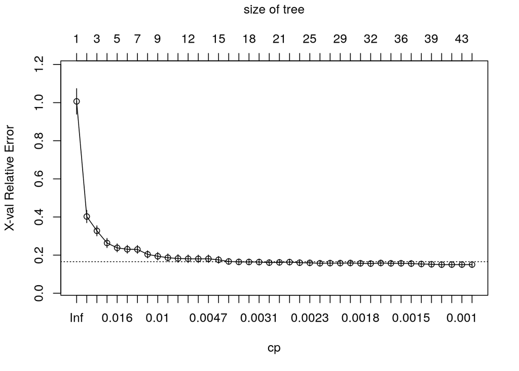

```r
plotcp(t4)
```

- A veces este gráfico tiene un mínimo, por lo que deberíamos seleccionar ese arbol. En caso contrario, elegimos el tamaño donde el error se estabilice.
- Según el gráfico y la tabla anterior, un arbol de 12 hojas parece razonable.

```r
(t4_cp = t4_printcp[12,"CP"])
```

```
## [1] 0.005458475
```

- Ahora podamos el arbol:

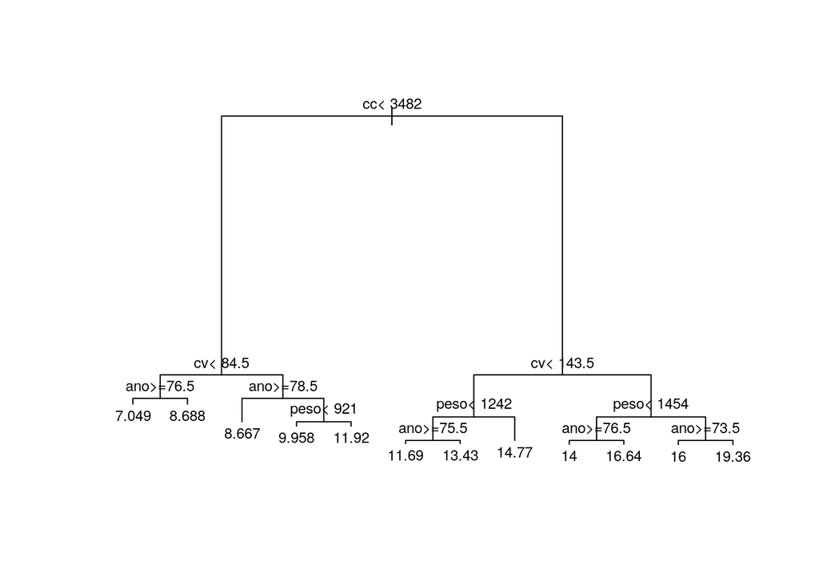

```r
t4_prune = prune(t4, cp = t4_cp)
plot(t4_prune, margin = 0.02)
text(t4_prune, cex=.75)
```

# 3 Prediccion

```r
xp = data.frame(cc = 4500, cv = 110, peso = 950, acel = 13,
                ano = 70, origen = "Europa", cilindros = 8)
predict(t4_prune, newdata = xp)
```

```
##        1
## 13.42857
```

- Mirando el arbol se puede verificar fácilmente la predicción.